# Project: Wrangling and Analyze Data

## Data Gathering

In the cell below, gather **all** three pieces of data for this project and load them in the notebook. **Note:** the methods required to gather each data are different.

1. Directly download the WeRateDogs Twitter archive data (twitter_archive_enhanced.csv)

```python
# Import needed libraries

import pandas as pd # data wrangling
import numpy as np # mathematical calculations
import time # timer functions
import json # work with json files
import os # write files to disk
from PIL import Image # read Image files
from io import BytesIO # decode image files
import matplotlib.pyplot as plt # visualizations
```

```python
# Read the archived data provided into pandas dataframe

enhanced_twitter_archive = pd.read_csv("twitter-archive-enhanced.csv")
```

```python
# View sample of archive data
enhanced_twitter_archive.sample(3)
```

|  | tweet_id | in_reply_to_status_id | in_reply_to_user_id | timestamp | source | text | retweeted_status_id | retweeted_status_user_id | retweeted_status_timestamp | expanded_urls | rating_numerator | rating_denominator | name | doggo | floofer | pupper | puppo |
| --- | --- | --- | --- | --- | --- | --- | --- | --- | --- | --- | --- | --- | --- | --- | --- | --- | --- |
| 786 | 774757898236878852 | NaN | NaN | 2016-09-10 23:54:11 +0000 | <a href="http://twitter.com/download/iphone" r... | This is Finley. She's a Beneboop Cumbersplash.... | NaN | NaN | NaN | https://twitter.com/dog_rates/status/774757898... | 12 | 10 | Finley | None | None | None | None |
| 2198 | 668815180734689280 | NaN | NaN | 2015-11-23 15:35:39 +0000 | <a href="http://twitter.com/download/iphone" r... | This is a wild Toblerone from Papua New Guinea... | NaN | NaN | NaN | https://twitter.com/dog_rates/status/668815180... | 7 | 10 | a | None | None | None | None |
| 1670 | 682406705142087680 | NaN | NaN | 2015-12-31 03:43:31 +0000 | <a href="http://twitter.com/download/iphone" r... | This is Patrick. He's a bigass pupper. 7/10 ht... | NaN | NaN | NaN | https://twitter.com/dog_rates/status/682406705... | 7 | 10 | Patrick | None | None | pupper | None |

```python
twitter_arc_ids = enhanced_twitter_archive["tweet_id"]

twitter_arc_ids
```

```
0       892420643555336193
1       892177421306343426
2       891815181378084864
3       891689557279858688
4       891327558926688256
               ...
2351    666049248165822465
2352    666044226329800704
2353    666033412701032449
2354    666029285002620928
2355    666020888022790149
Name: tweet_id, Length: 2356, dtype: int64
```

1. Use the Requests library to download the tweet image prediction (image_predictions.tsv)

```python
import requests

r = requests.get("https://d17h27t6h515a5.cloudfront.net/topher/2017/August/599fd2ad_image-predictions/image-predictions.tsv")
```

```python
r.status_code
```

```
200
```

```python
# Download the response into tsv file

with open("image_predictions.tsv", mode='wb') as file:
    file.write(r.content)
```

```python
#  read provided image predictions into dataframe

image_predictions = pd.read_csv("image_predictions.tsv", sep="\t")
```

1. Use the Tweepy library to query additional data via the Twitter API (tweet_json.txt)

```python
# Import the tweepy library and Authenticate

import tweepy

consumer_key = 'redacted'
consumer_secret = 'redacted'
access_token = 'redacted'
access_secret = 'redacted'

auth = tweepy.OAuth1UserHandler(
   consumer_key, consumer_secret, access_token, access_secret
)

api = tweepy.API(auth, wait_on_rate_limit=True, wait_on_rate_limit_notify=True)
```

```python
# Read content of the api response and write into json format
counter = 0
failures = {}
begin_time = time.time()

with open("tweet_json.txt", "w") as tweet_json:
    for tweet_id in twitter_arc_ids:
        counter += 1
        print(f"Tweet {counter} : {tweet_id}")
        try:
            tweet = api.get_status(tweet_id, tweet_mode="extended")
            print("Sucess")
            json.dump(tweet._json, tweet_json)
            tweet_json.write("\n")
        except tweepy.errors.HTTPException as e:
            print("Fail")
            failures[tweet_id] = e
            pass

run_time = round(time.time() - begin_time, 2)
```

```python
print(f"It took {run_time} seconds to get {counter} tweets")
```

```
It took 1639.08 seconds to get 2356 tweets
```

```python
# read tweet_json file line by line for retweet id, retweeted status, retweet counts and favorite counts
tweets_info_list = []

with open("tweet_json.txt", "r") as f:
    for line in f:
        tweets_info_dict = json.loads(line)
        tweet_id = tweets_info_dict["id"]
        tweet_retweeted = tweets_info_dict["retweeted"]
        tweet_retweet_count = tweets_info_dict["retweet_count"]
        tweet_fav_count = tweets_info_dict["favorite_count"]
        tweets_info_list.append(
            {"tweet_id" : tweet_id,
            "tweet_retweeted" : tweet_retweeted,
            "tweet_retweet_count": tweet_retweet_count,
            "tweet_fav_count" : tweet_fav_count}
        )

type(tweets_info_list)
```

```
list
```

```python
# Check for all keys in the loaded tweets info dictionary
tweets_info_dict.keys()
```

[output not shown]

```python
# Convert data downloaded from twitter api to pandas dataframe
twitter_api_data = pd.DataFrame(tweets_info_list)
```

## Assessing Data

In this section, detect and document at least **eight (8) quality issues and two (2) tidiness issue**. You must use **both** visual assessment programmatic assessement to assess the data.

**Note:** pay attention to the following key points when you access the data.

Visually assess enhanced twitter archive dataset

```python
enhanced_twitter_archive
```

|  | tweet_id | in_reply_to_status_id | in_reply_to_user_id | timestamp | source | text | retweeted_status_id | retweeted_status_user_id | retweeted_status_timestamp | expanded_urls | rating_numerator | rating_denominator | name | doggo | floofer | pupper | puppo |
| --- | --- | --- | --- | --- | --- | --- | --- | --- | --- | --- | --- | --- | --- | --- | --- | --- | --- |
| 0 | 892420643555336193 | NaN | NaN | 2017-08-01 16:23:56 +0000 | <a href="http://twitter.com/download/iphone" r... | This is Phineas. He's a mystical boy. Only eve... | NaN | NaN | NaN | https://twitter.com/dog_rates/status/892420643... | 13 | 10 | Phineas | None | None | None | None |
| 1 | 892177421306343426 | NaN | NaN | 2017-08-01 00:17:27 +0000 | <a href="http://twitter.com/download/iphone" r... | This is Tilly. She's just checking pup on you.... | NaN | NaN | NaN | https://twitter.com/dog_rates/status/892177421... | 13 | 10 | Tilly | None | None | None | None |
| 2 | 891815181378084864 | NaN | NaN | 2017-07-31 00:18:03 +0000 | <a href="http://twitter.com/download/iphone" r... | This is Archie. He is a rare Norwegian Pouncin... | NaN | NaN | NaN | https://twitter.com/dog_rates/status/891815181... | 12 | 10 | Archie | None | None | None | None |
| 3 | 891689557279858688 | NaN | NaN | 2017-07-30 15:58:51 +0000 | <a href="http://twitter.com/download/iphone" r... | This is Darla. She commenced a snooze mid meal... | NaN | NaN | NaN | https://twitter.com/dog_rates/status/891689557... | 13 | 10 | Darla | None | None | None | None |
| 4 | 891327558926688256 | NaN | NaN | 2017-07-29 16:00:24 +0000 | <a href="http://twitter.com/download/iphone" r... | This is Franklin. He would like you to stop ca... | NaN | NaN | NaN | https://twitter.com/dog_rates/status/891327558... | 12 | 10 | Franklin | None | None | None | None |
| ... | ... | ... | ... | ... | ... | ... | ... | ... | ... | ... | ... | ... | ... | ... | ... | ... | ... |
| 2351 | 666049248165822465 | NaN | NaN | 2015-11-16 00:24:50 +0000 | <a href="http://twitter.com/download/iphone" r... | Here we have a 1949 1st generation vulpix. Enj... | NaN | NaN | NaN | https://twitter.com/dog_rates/status/666049248... | 5 | 10 | None | None | None | None | None |
| 2352 | 666044226329800704 | NaN | NaN | 2015-11-16 00:04:52 +0000 | <a href="http://twitter.com/download/iphone" r... | This is a purebred Piers Morgan. Loves to Netf... | NaN | NaN | NaN | https://twitter.com/dog_rates/status/666044226... | 6 | 10 | a | None | None | None | None |
| 2353 | 666033412701032449 | NaN | NaN | 2015-11-15 23:21:54 +0000 | <a href="http://twitter.com/download/iphone" r... | Here is a very happy pup. Big fan of well-main... | NaN | NaN | NaN | https://twitter.com/dog_rates/status/666033412... | 9 | 10 | a | None | None | None | None |
| 2354 | 666029285002620928 | NaN | NaN | 2015-11-15 23:05:30 +0000 | <a href="http://twitter.com/download/iphone" r... | This is a western brown Mitsubishi terrier. Up... | NaN | NaN | NaN | https://twitter.com/dog_rates/status/666029285... | 7 | 10 | a | None | None | None | None |
| 2355 | 666020888022790149 | NaN | NaN | 2015-11-15 22:32:08 +0000 | <a href="http://twitter.com/download/iphone" r... | Here we have a Japanese Irish Setter. Lost eye... | NaN | NaN | NaN | https://twitter.com/dog_rates/status/666020888... | 8 | 10 | None | None | None | None | None |

2356 rows × 17 columns

Visually assess image prediction dataset

```python
image_predictions
```

|  | tweet_id | jpg_url | img_num | p1 | p1_conf | p1_dog | p2 | p2_conf | p2_dog | p3 | p3_conf | p3_dog |
| --- | --- | --- | --- | --- | --- | --- | --- | --- | --- | --- | --- | --- |
| 0 | 666020888022790149 | https://pbs.twimg.com/media/CT4udn0WwAA0aMy.jpg | 1 | Welsh_springer_spaniel | 0.465074 | True | collie | 0.156665 | True | Shetland_sheepdog | 0.061428 | True |
| 1 | 666029285002620928 | https://pbs.twimg.com/media/CT42GRgUYAA5iDo.jpg | 1 | redbone | 0.506826 | True | miniature_pinscher | 0.074192 | True | Rhodesian_ridgeback | 0.072010 | True |
| 2 | 666033412701032449 | https://pbs.twimg.com/media/CT4521TWwAEvMyu.jpg | 1 | German_shepherd | 0.596461 | True | malinois | 0.138584 | True | bloodhound | 0.116197 | True |
| 3 | 666044226329800704 | https://pbs.twimg.com/media/CT5Dr8HUEAA-lEu.jpg | 1 | Rhodesian_ridgeback | 0.408143 | True | redbone | 0.360687 | True | miniature_pinscher | 0.222752 | True |
| 4 | 666049248165822465 | https://pbs.twimg.com/media/CT5IQmsXIAAKY4A.jpg | 1 | miniature_pinscher | 0.560311 | True | Rottweiler | 0.243682 | True | Doberman | 0.154629 | True |
| ... | ... | ... | ... | ... | ... | ... | ... | ... | ... | ... | ... | ... |
| 2070 | 891327558926688256 | https://pbs.twimg.com/media/DF6hr6BUMAAzZgT.jpg | 2 | basset | 0.555712 | True | English_springer | 0.225770 | True | German_short-haired_pointer | 0.175219 | True |
| 2071 | 891689557279858688 | https://pbs.twimg.com/media/DF_q7IAWsAEuuN8.jpg | 1 | paper_towel | 0.170278 | False | Labrador_retriever | 0.168086 | True | spatula | 0.040836 | False |
| 2072 | 891815181378084864 | https://pbs.twimg.com/media/DGBdLU1WsAANxJ9.jpg | 1 | Chihuahua | 0.716012 | True | malamute | 0.078253 | True | kelpie | 0.031379 | True |
| 2073 | 892177421306343426 | https://pbs.twimg.com/media/DGGmoV4XsAAUL6n.jpg | 1 | Chihuahua | 0.323581 | True | Pekinese | 0.090647 | True | papillon | 0.068957 | True |
| 2074 | 892420643555336193 | https://pbs.twimg.com/media/DGKD1-bXoAAIAUK.jpg | 1 | orange | 0.097049 | False | bagel | 0.085851 | False | banana | 0.076110 | False |

2075 rows × 12 columns

Visually assess data containing tweet information gotten via twitter API

```python
twitter_api_data
```

|  | tweet_id | tweet_retweeted | tweet_retweet_count | tweet_fav_count |
| --- | --- | --- | --- | --- |
| 0 | 892420643555336193 | False | 7007 | 33809 |
| 1 | 892177421306343426 | False | 5301 | 29328 |
| 2 | 891815181378084864 | False | 3480 | 22048 |
| 3 | 891689557279858688 | False | 7226 | 36935 |
| 4 | 891327558926688256 | False | 7760 | 35310 |
| ... | ... | ... | ... | ... |
| 1766 | 669753178989142016 | False | 341 | 709 |
| 1767 | 669749430875258880 | False | 55 | 229 |
| 1768 | 669684865554620416 | False | 75 | 448 |
| 1769 | 669683899023405056 | False | 94 | 339 |
| 1770 | 669682095984410625 | False | 116 | 312 |

1771 rows × 4 columns

programmatically assess the twitter archive dataset (dataset1)

```python
# Get random samples from dataset 1
enhanced_twitter_archive.sample(4)
```

|  | tweet_id | in_reply_to_status_id | in_reply_to_user_id | timestamp | source | text | retweeted_status_id | retweeted_status_user_id | retweeted_status_timestamp | expanded_urls | rating_numerator | rating_denominator | name | doggo | floofer | pupper | puppo |
| --- | --- | --- | --- | --- | --- | --- | --- | --- | --- | --- | --- | --- | --- | --- | --- | --- | --- |
| 920 | 756303284449767430 | NaN | NaN | 2016-07-22 01:42:09 +0000 | <a href="http://twitter.com/download/iphone" r... | Pwease accept dis rose on behalf of dog. 11/10... | NaN | NaN | NaN | https://twitter.com/dog_rates/status/756303284... | 11 | 10 | None | None | None | None | None |
| 1160 | 724004602748780546 | NaN | NaN | 2016-04-23 22:38:43 +0000 | <a href="http://twitter.com/download/iphone" r... | This is Luther. He saw a ghost. Spooked af. 11... | NaN | NaN | NaN | https://twitter.com/dog_rates/status/724004602... | 11 | 10 | Luther | None | None | pupper | None |
| 1970 | 673295268553605120 | NaN | NaN | 2015-12-06 00:17:55 +0000 | <a href="http://twitter.com/download/iphone" r... | Meet Eve. She's a raging alcoholic 8/10 (would... | NaN | NaN | NaN | https://twitter.com/dog_rates/status/673295268... | 8 | 10 | Eve | None | None | pupper | None |
| 1178 | 719551379208073216 | NaN | NaN | 2016-04-11 15:43:12 +0000 | <a href="http://twitter.com/download/iphone" r... | This is Harnold. He accidentally opened the fr... | NaN | NaN | NaN | https://twitter.com/dog_rates/status/719551379... | 10 | 10 | Harnold | None | None | None | None |

```python
# get general info on dataset1
enhanced_twitter_archive.info()
```

```
<class 'pandas.core.frame.DataFrame'>
RangeIndex: 2356 entries, 0 to 2355
Data columns (total 17 columns):
 #   Column                      Non-Null Count  Dtype
---  ------                      --------------  -----
 0   tweet_id                    2356 non-null   int64
 1   in_reply_to_status_id       78 non-null     float64
 2   in_reply_to_user_id         78 non-null     float64
 3   timestamp                   2356 non-null   object
 4   source                      2356 non-null   object
 5   text                        2356 non-null   object
 6   retweeted_status_id         181 non-null    float64
 7   retweeted_status_user_id    181 non-null    float64
 8   retweeted_status_timestamp  181 non-null    object
 9   expanded_urls               2297 non-null   object
 10  rating_numerator            2356 non-null   int64
 11  rating_denominator          2356 non-null   int64
 12  name                        2356 non-null   object
 13  doggo                       2356 non-null   object
 14  floofer                     2356 non-null   object
 15  pupper                      2356 non-null   object
 16  puppo                       2356 non-null   object
dtypes: float64(4), int64(3), object(10)
memory usage: 313.0+ KB
```

```python
# get the number of names in the dataset that are duplicated.
enhanced_twitter_archive["name"].duplicated().sum()
```

```
1399
```

```python
# get the counts of the names in dataset
enhanced_twitter_archive["name"].value_counts()
```

```
None          745
a              55
Charlie        12
Cooper         11
Lucy           11
             ...
Dex             1
Ace             1
Tayzie          1
Grizzie         1
Christoper      1
Name: name, Length: 957, dtype: int64
```

```python
enhanced_twitter_archive["name"].nunique()
```

```
957
```

```python
enhanced_twitter_archive["name"].sample(20)
```

```
1123     Crystal
652         BeBe
2328        None
1553    Clarence
1640      Sweets
1451       Wyatt
1268       Cecil
1043        None
1067       Baloo
1814        None
881         None
99          None
678       Stella
2065        None
1418     Jessiga
1626    Theodore
2149        None
1093        None
1414     Cuddles
656       Maddie
Name: name, dtype: object
```

```python
# get the number of observations that are not retweets
enhanced_twitter_archive["retweeted_status_user_id"].isnull().sum()
```

```
2175
```

```python
# descriptive summary of numerical variables for dataset 1
enhanced_twitter_archive.describe().style.format("{0:,.0f}")
```

|  | tweet_id | in_reply_to_status_id | in_reply_to_user_id | retweeted_status_id | retweeted_status_user_id | rating_numerator | rating_denominator |
| --- | --- | --- | --- | --- | --- | --- | --- |
| count | 2,356 | 78 | 78 | 181 | 181 | 2,356 | 2,356 |
| mean | 742,771,590,321,719,808 | 745,507,917,855,750,656 | 20,141,706,360,873,208 | 772,039,961,038,007,040 | 12,416,983,653,017,580 | 13 | 10 |
| std | 68,567,047,444,761,032 | 75,824,920,044,192,880 | 125,279,666,255,236,320 | 62,369,278,105,055,600 | 95,992,535,331,517,536 | 46 | 7 |
| min | 666,020,888,022,790,144 | 665,814,696,700,723,200 | 11,856,342 | 666,104,133,288,665,088 | 783,214 | 0 | 0 |
| 25% | 678,398,938,214,475,776 | 675,741,911,993,464,832 | 308,637,449 | 718,631,497,683,582,976 | 4,196,983,835 | 10 | 10 |
| 50% | 719,627,934,716,235,776 | 703,870,840,226,598,912 | 4,196,983,835 | 780,465,709,297,995,776 | 4,196,983,835 | 11 | 10 |
| 75% | 799,337,304,954,252,288 | 825,780,371,286,566,912 | 4,196,983,835 | 820,314,633,777,061,888 | 4,196,983,835 | 12 | 10 |
| max | 892,420,643,555,336,192 | 886,266,357,075,128,320 | 840,547,864,354,918,400 | 887,473,957,103,951,872 | 787,461,778,435,289,088 | 1,776 | 170 |

```python
# check dataset for extremely high ratings that might constitute bias
enhanced_twitter_archive.query('rating_numerator > 50').info()
```

```
<class 'pandas.core.frame.DataFrame'>
Int64Index: 18 entries, 188 to 2074
Data columns (total 17 columns):
 #   Column                      Non-Null Count  Dtype
---  ------                      --------------  -----
 0   tweet_id                    18 non-null     int64
 1   in_reply_to_status_id       5 non-null      float64
 2   in_reply_to_user_id         5 non-null      float64
 3   timestamp                   18 non-null     object
 4   source                      18 non-null     object
 5   text                        18 non-null     object
 6   retweeted_status_id         1 non-null      float64
 7   retweeted_status_user_id    1 non-null      float64
 8   retweeted_status_timestamp  1 non-null      object
 9   expanded_urls               14 non-null     object
 10  rating_numerator            18 non-null     int64
 11  rating_denominator          18 non-null     int64
 12  name                        18 non-null     object
 13  doggo                       18 non-null     object
 14  floofer                     18 non-null     object
 15  pupper                      18 non-null     object
 16  puppo                       18 non-null     object
dtypes: float64(4), int64(3), object(10)
memory usage: 2.5+ KB
```

programmatically assess the image prediction dataset (dataset 2)

```python
# view samples from the dataset
image_predictions.sample(5)
```

|  | tweet_id | jpg_url | img_num | p1 | p1_conf | p1_dog | p2 | p2_conf | p2_dog | p3 | p3_conf | p3_dog |
| --- | --- | --- | --- | --- | --- | --- | --- | --- | --- | --- | --- | --- |
| 1646 | 808501579447930884 | https://pbs.twimg.com/media/Czhf4XtVQAAIqpd.jpg | 2 | Airedale | 0.454239 | True | cocker_spaniel | 0.219323 | True | Irish_terrier | 0.093193 | True |
| 1211 | 742528092657332225 | https://pbs.twimg.com/media/Ck39W0JWUAApgnH.jpg | 2 | sunglasses | 0.900864 | False | sunglass | 0.040291 | False | snorkel | 0.009333 | False |
| 1029 | 711008018775851008 | https://pbs.twimg.com/media/Cd4CBQFW8AAY3ND.jpg | 1 | French_bulldog | 0.731405 | True | Boston_bull | 0.150672 | True | pug | 0.021811 | True |
| 57 | 667073648344346624 | https://pbs.twimg.com/media/CUHr8WbWEAEBPgf.jpg | 1 | Chihuahua | 0.483682 | True | pug | 0.092494 | True | Brabancon_griffon | 0.057495 | True |
| 958 | 705475953783398401 | https://pbs.twimg.com/media/CcpaoR9WAAAKlJJ.jpg | 1 | golden_retriever | 0.908784 | True | Labrador_retriever | 0.030361 | True | tennis_ball | 0.004996 | False |

```python
# assess summary of each series in dataset 2
image_predictions.info()
```

```
<class 'pandas.core.frame.DataFrame'>
RangeIndex: 2075 entries, 0 to 2074
Data columns (total 12 columns):
 #   Column    Non-Null Count  Dtype
---  ------    --------------  -----
 0   tweet_id  2075 non-null   int64
 1   jpg_url   2075 non-null   object
 2   img_num   2075 non-null   int64
 3   p1        2075 non-null   object
 4   p1_conf   2075 non-null   float64
 5   p1_dog    2075 non-null   bool
 6   p2        2075 non-null   object
 7   p2_conf   2075 non-null   float64
 8   p2_dog    2075 non-null   bool
 9   p3        2075 non-null   object
 10  p3_conf   2075 non-null   float64
 11  p3_dog    2075 non-null   bool
dtypes: bool(3), float64(3), int64(2), object(4)
memory usage: 152.1+ KB
```

```python
# download all images in the image prediction dataset

# Create a directory if it doesn't already exist
folder_name = 'dog_images'
if not os.path.exists(folder_name):
    os.makedirs(folder_name)

for x in range(0, len(image_predictions)):
    try:
        tweet_id = image_predictions["tweet_id"][x]
        image = requests.get(image_predictions["jpg_url"][x])
        Image.open(BytesIO(image.content)).save(folder_name + "/" + str(tweet_id) + '.' + "jpg")

    except Exception as e:
        print(f"Error with {tweet_id} : {e}")
```

```python
# Get summary of numerical variables
image_predictions.describe().style.format("{0:,.0f}")
```

|  | tweet_id | img_num | p1_conf | p2_conf | p3_conf |
| --- | --- | --- | --- | --- | --- |
| count | 2,075 | 2,075 | 2,075 | 2,075 | 2,075 |
| mean | 738,451,357,852,539,008 | 1 | 1 | 0 | 0 |
| std | 67,852,033,330,235,656 | 1 | 0 | 0 | 0 |
| min | 666,020,888,022,790,144 | 1 | 0 | 0 | 0 |
| 25% | 676,483,507,139,540,992 | 1 | 0 | 0 | 0 |
| 50% | 711,998,809,858,043,904 | 1 | 1 | 0 | 0 |
| 75% | 793,203,448,525,178,880 | 1 | 1 | 0 | 0 |
| max | 892,420,643,555,336,192 | 4 | 1 | 0 | 0 |

programmatically assess api gathered dataset (dataset 3)

```python
# Get information of dataset
twitter_api_data.info()
```

```
<class 'pandas.core.frame.DataFrame'>
RangeIndex: 1771 entries, 0 to 1770
Data columns (total 4 columns):
 #   Column               Non-Null Count  Dtype
---  ------               --------------  -----
 0   tweet_id             1771 non-null   int64
 1   tweet_retweeted      1771 non-null   bool
 2   tweet_retweet_count  1771 non-null   int64
 3   tweet_fav_count      1771 non-null   int64
dtypes: bool(1), int64(3)
memory usage: 43.4 KB
```

```python
# pick random samples from dataset
twitter_api_data.sample(10)
```

|  | tweet_id | tweet_retweeted | tweet_retweet_count | tweet_fav_count |
| --- | --- | --- | --- | --- |
| 142 | 863427515083354112 | False | 80 | 1961 |
| 1457 | 675898130735476737 | False | 505 | 1448 |
| 1351 | 679828447187857408 | False | 12607 | 33194 |
| 1557 | 673906403526995968 | False | 1438 | 2847 |
| 747 | 777621514455814149 | False | 2341 | 8223 |
| 1728 | 670449342516494336 | False | 570 | 1076 |
| 1686 | 671141549288370177 | False | 572 | 1024 |
| 1756 | 670046952931721218 | False | 152 | 576 |
| 1350 | 679844490799091713 | False | 687 | 2186 |
| 1421 | 676949632774234114 | False | 348 | 1188 |

```python
# Get statisticak summary for dataset 3
twitter_api_data.describe().style.format("{0:,.0f}")
```

|  | tweet_id | tweet_retweet_count | tweet_fav_count |
| --- | --- | --- | --- |
| count | 1,771 | 1,771 | 1,771 |
| mean | 751,366,856,863,915,392 | 2,731 | 7,941 |
| std | 73,096,232,396,284,832 | 4,109 | 11,354 |
| min | 669,682,095,984,410,624 | 1 | 0 |
| 25% | 680,800,102,202,632,192 | 562 | 1,392 |
| 50% | 709,901,256,215,666,688 | 1,362 | 3,116 |
| 75% | 817,657,043,551,162,368 | 3,231 | 10,587 |
| max | 892,420,643,555,336,192 | 51,675 | 124,103 |

### Quality issues

1. `dataset 1`: The `timestamp` column are in object type, as against being in datetime type.
2. `dataset 1`: name column has a lot of words such as "None" and "a", "an", etc which do not represent real names.
3. `dataset 1`: some extreme outliers on the ratings columns.
4. `dataset 1`: some of the dataset rows are retweets and shoult not count as part of the dataset.
5. `dataset 1`: some of the columns are missing a lot of values and some are not needed for the purpose of our analysis.
6. `dataset 2`: some of the images in the link provided are not pictures of dogs.
7. `dataset 2`: There is a lack of consistency in the cases (mixed upper and lower cases) for the predictions (p1, p2, p3).
8. `dataset 2`: The `jpg_url` column can be dropped as it is not needed for our analysis.
9. `dataset 1`: The "None" in the doggo, floofer, pupper, puppo columns are missing values and should be treated as such.

### Tidiness issues

1. `dataset 1`: four columns with the dog's stage (doggo, floofer, pupper, puppo) should be all in the same column.
2. `dataset 1`, `dataset 2`, and `dataset 3`: should be combined into one dataset since they form one observational unit.

## Cleaning Data

In this section, clean **all** of the issues you documented while assessing.

**Note:** Make a copy of the original data before cleaning. Cleaning includes merging individual pieces of data according to the rules of [tidy data](https://cran.r-project.org/web/packages/tidyr/vignettes/tidy-data.html). The result should be a high-quality and tidy master pandas DataFrame (or DataFrames, if appropriate).

```python
# instantiate a function that will be used for dropping columns throughout the cleaning process.
def drop_df_cols(df, cols_to_drop):
    """
    this function takes in two parameters - df (a dataframe) and cols_to_drop (a list of columns)
    and drops the columns.
    """
    for col in cols_to_drop:
        df.drop(columns=col, inplace=True)
    return df.head(2)
```

```python
# Make copies of original pieces of data
enhanced_twitter_archive_clean = enhanced_twitter_archive.copy()
image_predictions_clean = image_predictions.copy()
twitter_api_data_clean = twitter_api_data.copy()
```

### Issue #1:

#### Define:

Convert timestamp column to datetime datatype

#### Code

```python
enhanced_twitter_archive_clean["timestamp"] = pd.to_datetime(enhanced_twitter_archive_clean["timestamp"])
```

#### Test

```python
enhanced_twitter_archive_clean["timestamp"].dtype
```

```
datetime64[ns, UTC]
```

### Issue #2:

#### Define

Replace all words that are not names with "Name Unavailable" in dataset 1

#### Code

```python
# create a list of non-names found during visual assessment of dataset and replace each instance of the name.
list_non_names = ["a", "None", "all", "an", "by", "getting", "his",
                  "just", "life", "light", "mad", "my", "not", "old",
                  "one", "quite", "space", "the", "this", "unacceptable", "very"]

for item in list_non_names:
    enhanced_twitter_archive_clean["name"].replace(item, "Name Unavailable", inplace=True)
```

```python
# replace "O" in names with "O'Malley"
enhanced_twitter_archive_clean["name"].replace("O", "O'Malley", inplace=True)
```

#### Test

```python
#  confirm there are no names like "None", "a", "an", etc in dataset.
enhanced_twitter_archive_clean["name"].value_counts()
```

```
Name Unavailable    848
Charlie              12
Oliver               11
Cooper               11
Lucy                 11
                   ...
Beckham               1
Devón                 1
Gert                  1
Dex                   1
Christoper            1
Name: name, Length: 937, dtype: int64
```

```python
# confirm there is no dog with the name "O" in dataset
enhanced_twitter_archive_clean.query('name == "O"')
```

|  | tweet_id | in_reply_to_status_id | in_reply_to_user_id | timestamp | source | text | retweeted_status_id | retweeted_status_user_id | retweeted_status_timestamp | expanded_urls | rating_numerator | rating_denominator | name | doggo | floofer | pupper | puppo |
| --- | --- | --- | --- | --- | --- | --- | --- | --- | --- | --- | --- | --- | --- | --- | --- | --- | --- |

### Issue #3:

#### Define

Drop outlier ratings. For the purpose of this cleaning process, I will be dropping any ratings equal to or higher than 50.

#### Code

```python
#  mask dataframe to include only ratings below 50.
enhanced_twitter_archive_clean = enhanced_twitter_archive_clean.query('rating_numerator < 50')
enhanced_twitter_archive_clean = enhanced_twitter_archive_clean.query('rating_denominator < 50')
```

#### Test

```python
# confirm there are no datasets with ratings higher than 50
enhanced_twitter_archive_clean.describe().style.format("{0:,.0f}")
```

|  | tweet_id | in_reply_to_status_id | in_reply_to_user_id | retweeted_status_id | retweeted_status_user_id | rating_numerator | rating_denominator |
| --- | --- | --- | --- | --- | --- | --- | --- |
| count | 2,336 | 73 | 73 | 180 | 180 | 2,336 | 2,336 |
| mean | 742,704,800,927,771,776 | 740,825,796,186,616,192 | 21,521,275,228,697,864 | 771,958,465,916,830,208 | 12,485,966,872,217,768 | 11 | 10 |
| std | 68,593,374,754,350,128 | 74,195,613,216,839,824 | 129,440,420,764,057,680 | 62,533,586,713,814,240 | 96,255,798,436,530,464 | 2 | 1 |
| min | 666,020,888,022,790,144 | 665,814,696,700,723,200 | 11,856,342 | 666,104,133,288,665,088 | 783,214 | 0 | 2 |
| 25% | 678,386,830,676,510,720 | 675,497,103,322,386,432 | 1,198,988,510 | 717,175,879,759,181,824 | 4,196,983,835 | 10 | 10 |
| 50% | 719,627,934,716,235,776 | 703,041,949,650,034,688 | 4,196,983,835 | 780,150,020,947,441,664 | 4,196,983,835 | 11 | 10 |
| 75% | 799,300,023,567,684,608 | 813,127,251,579,564,032 | 4,196,983,835 | 820,423,404,544,218,112 | 4,196,983,835 | 12 | 10 |
| max | 892,420,643,555,336,192 | 886,266,357,075,128,320 | 840,547,864,354,918,400 | 887,473,957,103,951,872 | 787,461,778,435,289,088 | 44 | 40 |

### Issue #4:

#### Define

Drop rows that are retweets.

#### Code

```python
# drop rows containing retweets by filtering them out
enhanced_twitter_archive_clean = enhanced_twitter_archive_clean[enhanced_twitter_archive_clean["retweeted_status_id"].isnull()]
```

#### Test

```python
#  check to be sure there are no longer any entries in the retweet columns
enhanced_twitter_archive_clean.info()
```

```
<class 'pandas.core.frame.DataFrame'>
Int64Index: 2156 entries, 0 to 2355
Data columns (total 17 columns):
 #   Column                      Non-Null Count  Dtype
---  ------                      --------------  -----
 0   tweet_id                    2156 non-null   int64
 1   in_reply_to_status_id       73 non-null     float64
 2   in_reply_to_user_id         73 non-null     float64
 3   timestamp                   2156 non-null   datetime64[ns, UTC]
 4   source                      2156 non-null   object
 5   text                        2156 non-null   object
 6   retweeted_status_id         0 non-null      float64
 7   retweeted_status_user_id    0 non-null      float64
 8   retweeted_status_timestamp  0 non-null      object
 9   expanded_urls               2102 non-null   object
 10  rating_numerator            2156 non-null   int64
 11  rating_denominator          2156 non-null   int64
 12  name                        2156 non-null   object
 13  doggo                       2156 non-null   object
 14  floofer                     2156 non-null   object
 15  pupper                      2156 non-null   object
 16  puppo                       2156 non-null   object
dtypes: datetime64[ns, UTC](1), float64(4), int64(3), object(9)
memory usage: 303.2+ KB
```

### Issue #5:

#### Define

Drop the following columns which are missing a lot of values and are not likely needed for our analysis process - in_reply_to_status_id, in_reply_to_user_id, retweeted_status_id, retweeted_status_user_id, and retweeted_status_timestamp, etc.

#### Code

```python
# drop columns that are not useful for analysis
cols_to_drop = ["source", "text", "expanded_urls", "in_reply_to_status_id", "in_reply_to_user_id", "retweeted_status_id", "retweeted_status_user_id", "retweeted_status_timestamp"]

drop_df_cols(enhanced_twitter_archive_clean, cols_to_drop)
```

|  | tweet_id | timestamp | rating_numerator | rating_denominator | name | doggo | floofer | pupper | puppo |
| --- | --- | --- | --- | --- | --- | --- | --- | --- | --- |
| 0 | 892420643555336193 | 2017-08-01 16:23:56+00:00 | 13 | 10 | Phineas | None | None | None | None |
| 1 | 892177421306343426 | 2017-08-01 00:17:27+00:00 | 13 | 10 | Tilly | None | None | None | None |

#### Test

```python
# check to be sure dropped columns are no longer part of our dataframe
enhanced_twitter_archive_clean.info()
```

```
<class 'pandas.core.frame.DataFrame'>
Int64Index: 2156 entries, 0 to 2355
Data columns (total 9 columns):
 #   Column              Non-Null Count  Dtype
---  ------              --------------  -----
 0   tweet_id            2156 non-null   int64
 1   timestamp           2156 non-null   datetime64[ns, UTC]
 2   rating_numerator    2156 non-null   int64
 3   rating_denominator  2156 non-null   int64
 4   name                2156 non-null   object
 5   doggo               2156 non-null   object
 6   floofer             2156 non-null   object
 7   pupper              2156 non-null   object
 8   puppo               2156 non-null   object
dtypes: datetime64[ns, UTC](1), int64(3), object(5)
memory usage: 168.4+ KB
```

### Issue #6:

#### Define

Drop rows that have their image predictions as other animals apart from dogs.

#### Code

```python
#  filter out rows have p1_dog = False.
image_predictions_clean = image_predictions_clean[image_predictions_clean["p1_dog"] == True]
```

#### Test

```python
# check to be sure there are no p1 predictions that are not dogs.
image_predictions_clean["p1_dog"].value_counts()
```

```
True    1532
Name: p1_dog, dtype: int64
```

### Issue #7:

#### Define

Convert all prediction names to lower cases for consistency.

#### Code

```python
# convert all cases to lower in all prediction columns
cols_to_convert = ["p1", "p2", "p3"]

for cols in cols_to_convert:
    image_predictions_clean[cols] = image_predictions_clean[cols].str.lower()
```

#### Test

```python
# check dataframe to be sure all predictions are now in lower case.
image_predictions_clean
```

|  | tweet_id | jpg_url | img_num | p1 | p1_conf | p1_dog | p2 | p2_conf | p2_dog | p3 | p3_conf | p3_dog |
| --- | --- | --- | --- | --- | --- | --- | --- | --- | --- | --- | --- | --- |
| 0 | 666020888022790149 | https://pbs.twimg.com/media/CT4udn0WwAA0aMy.jpg | 1 | welsh_springer_spaniel | 0.465074 | True | collie | 0.156665 | True | shetland_sheepdog | 0.061428 | True |
| 1 | 666029285002620928 | https://pbs.twimg.com/media/CT42GRgUYAA5iDo.jpg | 1 | redbone | 0.506826 | True | miniature_pinscher | 0.074192 | True | rhodesian_ridgeback | 0.072010 | True |
| 2 | 666033412701032449 | https://pbs.twimg.com/media/CT4521TWwAEvMyu.jpg | 1 | german_shepherd | 0.596461 | True | malinois | 0.138584 | True | bloodhound | 0.116197 | True |
| 3 | 666044226329800704 | https://pbs.twimg.com/media/CT5Dr8HUEAA-lEu.jpg | 1 | rhodesian_ridgeback | 0.408143 | True | redbone | 0.360687 | True | miniature_pinscher | 0.222752 | True |
| 4 | 666049248165822465 | https://pbs.twimg.com/media/CT5IQmsXIAAKY4A.jpg | 1 | miniature_pinscher | 0.560311 | True | rottweiler | 0.243682 | True | doberman | 0.154629 | True |
| ... | ... | ... | ... | ... | ... | ... | ... | ... | ... | ... | ... | ... |
| 2068 | 890971913173991426 | https://pbs.twimg.com/media/DF1eOmZXUAALUcq.jpg | 1 | appenzeller | 0.341703 | True | border_collie | 0.199287 | True | ice_lolly | 0.193548 | False |
| 2069 | 891087950875897856 | https://pbs.twimg.com/media/DF3HwyEWsAABqE6.jpg | 1 | chesapeake_bay_retriever | 0.425595 | True | irish_terrier | 0.116317 | True | indian_elephant | 0.076902 | False |
| 2070 | 891327558926688256 | https://pbs.twimg.com/media/DF6hr6BUMAAzZgT.jpg | 2 | basset | 0.555712 | True | english_springer | 0.225770 | True | german_short-haired_pointer | 0.175219 | True |
| 2072 | 891815181378084864 | https://pbs.twimg.com/media/DGBdLU1WsAANxJ9.jpg | 1 | chihuahua | 0.716012 | True | malamute | 0.078253 | True | kelpie | 0.031379 | True |
| 2073 | 892177421306343426 | https://pbs.twimg.com/media/DGGmoV4XsAAUL6n.jpg | 1 | chihuahua | 0.323581 | True | pekinese | 0.090647 | True | papillon | 0.068957 | True |

1532 rows × 12 columns

### Issue #8:

#### Define

- Drop the `jpg_url` column from the predictions dataset

#### Code

```python
# drop the jpg_url column
cols_to_drop = ["jpg_url"]

drop_df_cols(image_predictions_clean, cols_to_drop)
```

|  | tweet_id | img_num | p1 | p1_conf | p1_dog | p2 | p2_conf | p2_dog | p3 | p3_conf | p3_dog |
| --- | --- | --- | --- | --- | --- | --- | --- | --- | --- | --- | --- |
| 0 | 666020888022790149 | 1 | welsh_springer_spaniel | 0.465074 | True | collie | 0.156665 | True | shetland_sheepdog | 0.061428 | True |
| 1 | 666029285002620928 | 1 | redbone | 0.506826 | True | miniature_pinscher | 0.074192 | True | rhodesian_ridgeback | 0.072010 | True |

#### Test

```python
# check to be sure the img_url column is not longer part of our dataframe
image_predictions_clean.info()
```

```
<class 'pandas.core.frame.DataFrame'>
Int64Index: 1532 entries, 0 to 2073
Data columns (total 11 columns):
 #   Column    Non-Null Count  Dtype
---  ------    --------------  -----
 0   tweet_id  1532 non-null   int64
 1   img_num   1532 non-null   int64
 2   p1        1532 non-null   object
 3   p1_conf   1532 non-null   float64
 4   p1_dog    1532 non-null   bool
 5   p2        1532 non-null   object
 6   p2_conf   1532 non-null   float64
 7   p2_dog    1532 non-null   bool
 8   p3        1532 non-null   object
 9   p3_conf   1532 non-null   float64
 10  p3_dog    1532 non-null   bool
dtypes: bool(3), float64(3), int64(2), object(3)
memory usage: 112.2+ KB
```

### Issue #9:

#### Define

Set all "None" values in doggo, floofer, pupper, puppo columns as missing values

#### Code

```python
# replace all values of the dog stages provided that are None with NaN.
cols_to_replace_none = ["doggo", "floofer", "pupper", "puppo"]

for col in cols_to_replace_none:
    enhanced_twitter_archive_clean[col] = enhanced_twitter_archive_clean[col].replace({"None":np.nan})
```

#### Test

```python
# check to be sure that all stages now have only the necessary stages
enhanced_twitter_archive_clean.info()
```

```
<class 'pandas.core.frame.DataFrame'>
Int64Index: 2156 entries, 0 to 2355
Data columns (total 9 columns):
 #   Column              Non-Null Count  Dtype
---  ------              --------------  -----
 0   tweet_id            2156 non-null   int64
 1   timestamp           2156 non-null   datetime64[ns, UTC]
 2   rating_numerator    2156 non-null   int64
 3   rating_denominator  2156 non-null   int64
 4   name                2156 non-null   object
 5   doggo               87 non-null     object
 6   floofer             10 non-null     object
 7   pupper              234 non-null    object
 8   puppo               25 non-null     object
dtypes: datetime64[ns, UTC](1), int64(3), object(5)
memory usage: 168.4+ KB
```

### Issue #10:

#### Define

- Combine all four dog stages in the separate columns to one column named "dog_stage"

#### Code

```python
# combine all four columns, then drop the individual stages in separate columns

enhanced_twitter_archive_clean["dog_stages"] = enhanced_twitter_archive_clean[["doggo", "floofer", "pupper", "puppo"]].apply(lambda x:','.join(x.dropna().astype(str)), axis=1)
```

```python
# drop columns
cols_to_drop = ["doggo", "floofer", "pupper", "puppo"]
drop_df_cols(enhanced_twitter_archive_clean, cols_to_drop)
```

|  | tweet_id | timestamp | rating_numerator | rating_denominator | name | dog_stages |
| --- | --- | --- | --- | --- | --- | --- |
| 0 | 892420643555336193 | 2017-08-01 16:23:56+00:00 | 13 | 10 | Phineas |  |
| 1 | 892177421306343426 | 2017-08-01 00:17:27+00:00 | 13 | 10 | Tilly |  |

#### Test

```python
# check all individual stages have been dropped and the dog_stage column was created
enhanced_twitter_archive_clean.info()
```

```
<class 'pandas.core.frame.DataFrame'>
Int64Index: 2156 entries, 0 to 2355
Data columns (total 6 columns):
 #   Column              Non-Null Count  Dtype
---  ------              --------------  -----
 0   tweet_id            2156 non-null   int64
 1   timestamp           2156 non-null   datetime64[ns, UTC]
 2   rating_numerator    2156 non-null   int64
 3   rating_denominator  2156 non-null   int64
 4   name                2156 non-null   object
 5   dog_stages          2156 non-null   object
dtypes: datetime64[ns, UTC](1), int64(3), object(2)
memory usage: 117.9+ KB
```

```python
# check for the value counts of the different dog stages captured
enhanced_twitter_archive_clean["dog_stages"].value_counts()
```

```
                 1812
pupper            224
doggo              75
puppo              24
doggo,pupper       10
floofer             9
doggo,puppo         1
doggo,floofer       1
Name: dog_stages, dtype: int64
```

### Issue #11:

#### Define

- Combine the twitter archive dataset *(enhanced_twitter_archive_clean)*, image predictions dataset *(image_predictions_clean)* and the api gathered dataset *(twitter_api_data_clean)* to form one master dataset.

#### Code

```python
enhanced_twitter_archive_clean.info()
```

```
<class 'pandas.core.frame.DataFrame'>
Int64Index: 2156 entries, 0 to 2355
Data columns (total 6 columns):
 #   Column              Non-Null Count  Dtype
---  ------              --------------  -----
 0   tweet_id            2156 non-null   int64
 1   timestamp           2156 non-null   datetime64[ns, UTC]
 2   rating_numerator    2156 non-null   int64
 3   rating_denominator  2156 non-null   int64
 4   name                2156 non-null   object
 5   dog_stages          2156 non-null   object
dtypes: datetime64[ns, UTC](1), int64(3), object(2)
memory usage: 117.9+ KB
```

```python
image_predictions_clean.info()
```

```
<class 'pandas.core.frame.DataFrame'>
Int64Index: 1532 entries, 0 to 2073
Data columns (total 11 columns):
 #   Column    Non-Null Count  Dtype
---  ------    --------------  -----
 0   tweet_id  1532 non-null   int64
 1   img_num   1532 non-null   int64
 2   p1        1532 non-null   object
 3   p1_conf   1532 non-null   float64
 4   p1_dog    1532 non-null   bool
 5   p2        1532 non-null   object
 6   p2_conf   1532 non-null   float64
 7   p2_dog    1532 non-null   bool
 8   p3        1532 non-null   object
 9   p3_conf   1532 non-null   float64
 10  p3_dog    1532 non-null   bool
dtypes: bool(3), float64(3), int64(2), object(3)
memory usage: 112.2+ KB
```

```python
twitter_api_data_clean.info()
```

```
<class 'pandas.core.frame.DataFrame'>
RangeIndex: 1771 entries, 0 to 1770
Data columns (total 4 columns):
 #   Column               Non-Null Count  Dtype
---  ------               --------------  -----
 0   tweet_id             1771 non-null   int64
 1   tweet_retweeted      1771 non-null   bool
 2   tweet_retweet_count  1771 non-null   int64
 3   tweet_fav_count      1771 non-null   int64
dtypes: bool(1), int64(3)
memory usage: 43.4 KB
```

```python
# merge the twitter archived dataset with image prediction dataset
twitter_archive_first_merge = pd.merge(enhanced_twitter_archive_clean, image_predictions_clean, on=["tweet_id"])
```

```python
# merge the first combined dataset with the api gathered dataset to form our master dataset
twitter_archive_master = pd.merge(twitter_archive_first_merge, twitter_api_data_clean, on=["tweet_id"])
```

#### Test

```python
# check the general information of the new master dataframe
twitter_archive_master.info()
```

```
<class 'pandas.core.frame.DataFrame'>
Int64Index: 1094 entries, 0 to 1093
Data columns (total 19 columns):
 #   Column               Non-Null Count  Dtype
---  ------               --------------  -----
 0   tweet_id             1094 non-null   int64
 1   timestamp            1094 non-null   datetime64[ns, UTC]
 2   rating_numerator     1094 non-null   int64
 3   rating_denominator   1094 non-null   int64
 4   name                 1094 non-null   object
 5   dog_stages           1094 non-null   object
 6   img_num              1094 non-null   int64
 7   p1                   1094 non-null   object
 8   p1_conf              1094 non-null   float64
 9   p1_dog               1094 non-null   bool
 10  p2                   1094 non-null   object
 11  p2_conf              1094 non-null   float64
 12  p2_dog               1094 non-null   bool
 13  p3                   1094 non-null   object
 14  p3_conf              1094 non-null   float64
 15  p3_dog               1094 non-null   bool
 16  tweet_retweeted      1094 non-null   bool
 17  tweet_retweet_count  1094 non-null   int64
 18  tweet_fav_count      1094 non-null   int64
dtypes: bool(4), datetime64[ns, UTC](1), float64(3), int64(6), object(5)
memory usage: 141.0+ KB
```

```python
# view sample of our new master dataset
twitter_archive_master.sample(5)
```

|  | tweet_id | timestamp | rating_numerator | rating_denominator | name | dog_stages | img_num | p1 | p1_conf | p1_dog | p2 | p2_conf | p2_dog | p3 | p3_conf | p3_dog | tweet_retweeted | tweet_retweet_count | tweet_fav_count |
| --- | --- | --- | --- | --- | --- | --- | --- | --- | --- | --- | --- | --- | --- | --- | --- | --- | --- | --- | --- |
| 185 | 835297930240217089 | 2017-02-25 01:18:40+00:00 | 12 | 10 | Ash |  | 1 | rottweiler | 0.341276 | True | border_terrier | 0.336220 | True | gordon_setter | 0.045448 | True | False | 2747 | 15450 |
| 207 | 831322785565769729 | 2017-02-14 02:02:51+00:00 | 12 | 10 | Pete | doggo | 1 | old_english_sheepdog | 0.999715 | True | tibetan_terrier | 0.000046 | True | guinea_pig | 0.000041 | False | False | 1447 | 8757 |
| 251 | 821886076407029760 | 2017-01-19 01:04:45+00:00 | 13 | 10 | Jimison |  | 1 | golden_retriever | 0.266238 | True | cocker_spaniel | 0.223325 | True | irish_setter | 0.151631 | True | False | 2142 | 10681 |
| 529 | 709852847387627521 | 2016-03-15 21:24:41+00:00 | 12 | 10 | Name Unavailable |  | 2 | chihuahua | 0.945629 | True | pomeranian | 0.019204 | True | west_highland_white_terrier | 0.010134 | True | False | 1092 | 3244 |
| 726 | 688547210804498433 | 2016-01-17 02:23:42+00:00 | 9 | 10 | Frönq |  | 1 | papillon | 0.531279 | True | blenheim_spaniel | 0.214197 | True | border_collie | 0.053840 | True | False | 627 | 2405 |

## Storing Data

Save gathered, assessed, and cleaned master dataset to a CSV file named "twitter_archive_master.csv".

```python
twitter_archive_master.to_csv("twitter_archive_master.csv", index=False)
```

## Analyzing and Visualizing Data

In this section, analyze and visualize your wrangled data. You must produce at least **three (3) insights and one (1) visualization.**

```python
twitter_archive_master.describe().style.format("{0:,.0f}")
```

|  | tweet_id | rating_numerator | rating_denominator | img_num | p1_conf | p2_conf | p3_conf | tweet_retweet_count | tweet_fav_count |
| --- | --- | --- | --- | --- | --- | --- | --- | --- | --- |
| count | 1,094 | 1,094 | 1,094 | 1,094 | 1,094 | 1,094 | 1,094 | 1,094 | 1,094 |
| mean | 750,446,822,646,363,136 | 11 | 10 | 1 | 1 | 0 | 0 | 2,483 | 9,229 |
| std | 74,050,123,614,936,336 | 2 | 1 | 1 | 0 | 0 | 0 | 3,772 | 11,867 |
| min | 669,683,899,023,405,056 | 2 | 7 | 1 | 0 | 0 | 0 | 35 | 215 |
| 25% | 680,810,404,888,595,456 | 10 | 10 | 1 | 0 | 0 | 0 | 590 | 2,024 |
| 50% | 708,125,206,227,873,792 | 11 | 10 | 1 | 1 | 0 | 0 | 1,352 | 5,018 |
| 75% | 817,158,712,309,808,128 | 12 | 10 | 1 | 1 | 0 | 0 | 2,998 | 12,457 |
| max | 892,177,421,306,343,424 | 44 | 40 | 4 | 1 | 0 | 0 | 51,675 | 124,103 |

```python
# Check for number of observations in each dog stage
twitter_archive_master["dog_stages"].value_counts()
```

```
                 912
pupper           122
doggo             35
puppo             14
doggo,pupper       5
floofer            4
doggo,puppo        1
doggo,floofer      1
Name: dog_stages, dtype: int64
```

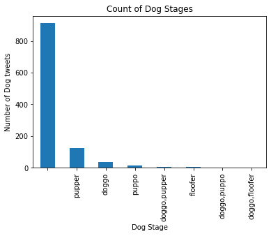

```python
# visualize count of dog stages
twitter_archive_master["dog_stages"].value_counts().plot(
    kind="bar",
    title="Count of Dog Stages",
    xlabel="Dog Stage",
    ylabel="Number of Dog tweets"
);
```

```python
#  which dog_stage has the highest likes on average
twitter_archive_master.groupby("dog_stages")["tweet_fav_count"].mean().sort_values().tail()
```

```
dog_stages
doggo,floofer    14842.000000
floofer          15153.500000
doggo            16831.485714
puppo            26090.714286
doggo,puppo      41912.000000
Name: tweet_fav_count, dtype: float64
```

```python
# what name(s) is/are most popular among dogs?
twitter_archive_master["name"].value_counts()
```

```
Name Unavailable    288
Charlie               9
Cooper                8
Penny                 7
Daisy                 7
                   ...
Chef                  1
Mauve                 1
Bones                 1
Milo                  1
Kloey                 1
Name: name, Length: 601, dtype: int64
```

```python
# most predicted dog breed
twitter_archive_master["p1"].value_counts()
```

```
golden_retriever           99
pembroke                   66
labrador_retriever         63
chihuahua                  62
pug                        42
                           ..
groenendael                 1
toy_terrier                 1
wire-haired_fox_terrier     1
clumber                     1
black-and-tan_coonhound     1
Name: p1, Length: 111, dtype: int64
```

### Insights:

1. Our cleaned master dataset now contains 1094 observations, all of which are original tweets. Of all the named dog stages contained in these tweets, the `pupper` stage is the most common of them all, occuring in 122 of them. There are also 5 other observations in which the `pupper` stage is included with another stage. It is also interesting to note, according to the data that the `doggo, puppo` combination has the highest likes on average.
2. Our data also shows us that **Charlie** seems to be the most popular name people call their dogs, followed closely by **Cooper**, and then by **Penny**.
3. The model predicted the `golden_retriever` breed of dogs the most, followed by `pembroke` breed, and then the `labrador_retriever` breed, with 99, 66, and 63 predictions respectively.
4. From the scatter plot visualization below, we can see a not-so-strong positive correlation between a dog's rating and number of likes. The highest amount of likes came from dogs with ratings from between 12 and 14.

### Visualization

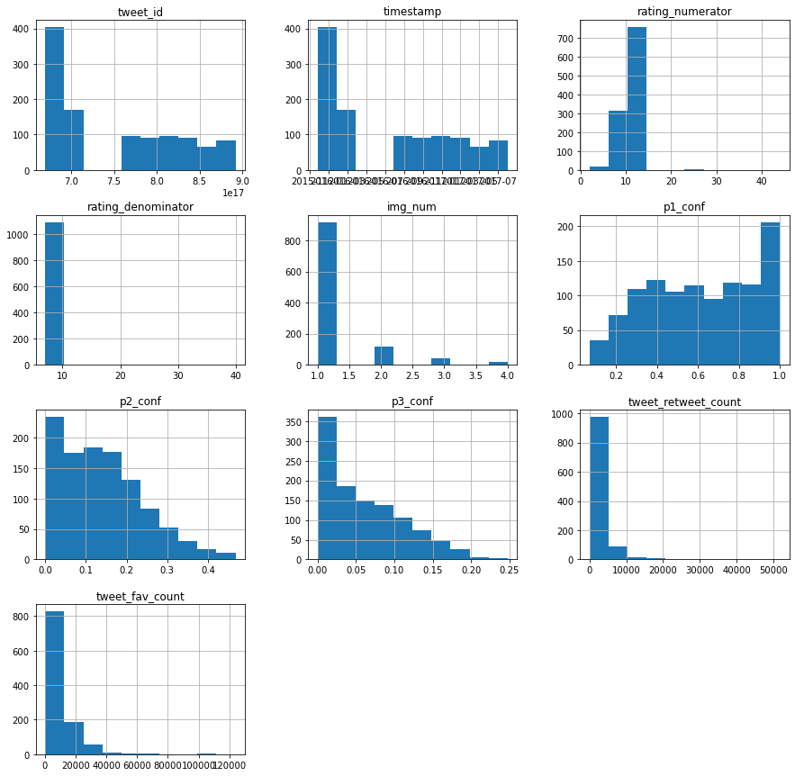

```python
# plot a histogram of numerical variables in dataset
twitter_archive_master.hist(figsize=(15, 15));
```

```
The coefficient of correlation between a dog's rating and the number of likes is: 0.3351
```

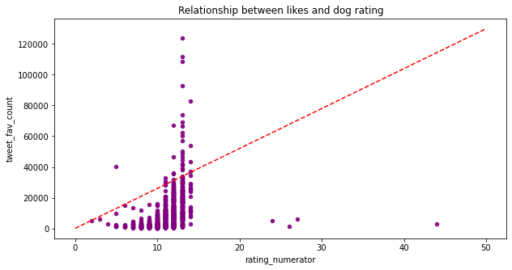

```python
# visualize the relationship between a dog's rating and the amount of likes the tweet gets.
fig, ax = plt.subplots(figsize=(10, 5))
ax.plot([0, 50], [0, 130000], linestyle="--", color="red")
twitter_archive_master.plot("rating_numerator",
                            "tweet_fav_count",
                            kind="scatter",
                            color="#800080",
                            title="Relationship between likes and dog rating",
                            ax=ax,
                            alpha=0.9);
print(f"The coefficient of correlation between a dog's rating and the number of likes is:", round(twitter_archive_master["rating_numerator"].corr(twitter_archive_master["tweet_fav_count"]), 4))
print()
```

### Resources

- [Tweepy Documentation](https://docs.tweepy.org/en/v4.10.0/getting_started.html)
- [Fetch Tweets Using Their IDs With Tweepy, Twitter API and Python - Amil Emrah](https://medium.com/analytics-vidhya/fetch-tweets-using-their-ids-with-tweepy-twitter-api-and-python-ee7a22dcb845)
- [Retrieve List of Tweets using Tweepy - Stack Overflow](https://stackoverflow.com/questions/44581647/retrieving-a-list-of-tweets-using-tweet-id-in-tweepy)
- [Create DataFrame from Python Dictionary - GeeksforGeeks](https://www.geeksforgeeks.org/how-to-create-dataframe-from-dictionary-in-python-pandas/)
- [Replace - Pandas Documentation](https://pandas.pydata.org/docs/reference/api/pandas.DataFrame.replace.html)
- [Convert strings to lowercase in Pandas - Data to fish](https://datatofish.com/lowercase-pandas-dataframe/)
- [Pandas Concat - Pandas Documentation](https://pandas.pydata.org/docs/reference/api/pandas.concat.html)
- [Fix TypeError: sequence item 0 - Stack Overflow](https://stackoverflow.com/questions/55998672/how-to-fix-this-typeerror-sequence-item-0-expected-str-instance-float-found)
- [Merge Pandas DataFrame - Pandas Documentation](https://pandas.pydata.org/pandas-docs/stable/reference/api/pandas.DataFrame.merge.html)